Download this document as a JupyterLab notebook [here](http://54.243.252.9/ce-3354-webroot/2-Exercises/ES-6/es6.ipynb)

# CE 3354 Engineering Hydrology Fall 2022 Exercise Set 6

**LAST NAME, FIRST NAME**

**R00000000**

### Purpose :

Streamflow flood-frequency analysis.

### Assessment Criteria :

Completion, plausible solutions, use of Jupyter Notebook as a calculator/documentation method

## Exercise 1

Figure 1 is a table of data representing gage height and annual peak discharge for some gaging station in Oklahoma. The stage is in feet and the discharge is in cubic feet per second. The data are sequential from 1923 through 1971 (1923 is the upper left-hand corner; 1971 is the lower right hand corner). Enter the data into a spreadsheet and analyze the data to product the following:

1. A plot of year versus stage ( x-axis is year).
2. A plot year versus discharge ( x-axis is year).
3. A plot the discharge versus stage (x-axis is discharge).
4. Using the Weibull plotting position formula, determine the distribution parameters that fit the data for a Gamma (Log-Pearson Type III) distribution.
5. Plot the empirical observations (use BLUE markers - no lines) and the fitted distribution (RED curve - no markers) on the same graph.
6. Estimate the discharge associated with a 25-percent chance exceedence probability (i.e. the value that is equal to or exceeded with a 1 in 4 chance).
7. A resident claims that in the early 1900s a flood corresponding to a stage of 30 feet occurred at the gage location. Estimate the exceedence probability (return period) of the flow associated with this event.

[figure not shown]

| Figure 1. Some Oklahoma Data |
| --- |

**Note 1** The data already put into a spreadsheet is located at OklahomaData.xlsx  
**Note 2** The data in PeakFQ format is located at OklahomaPeakFQFormat.txt.

> This data has a fake StationID and Lat/Log - don't use map skew unless you supply some Oklahoma relevant location (station skew should be fine as it is computed from the data)

## Solution

First load in the data

```python
import requests
remote_url="http://54.243.252.9/ce-3354-webroot/2-Exercises/ES-6/OklahomaData.xls"  # set the url
rget = requests.get(remote_url, allow_redirects=True)  # get the remote resource, follow imbedded links
open('data.xls','wb').write(rget.content);
```

```python
import pandas
df = pandas.read_excel('data.xls')
```

Examine the dataframe

```python
df.head()
```

|  | YEAR | STAGE | DISCHARGE |
| --- | --- | --- | --- |
| 0 | 1923 | 23.0 | 200000 |
| 1 | 1924 | 11.8 | 42000 |
| 2 | 1925 | 6.4 | 11300 |
| 3 | 1926 | 10.4 | 32400 |
| 4 | 1927 | 18.7 | 108000 |

A plot of year versus stage ( x-axis is year).

```python
y = df['YEAR']; s = df['STAGE']
```

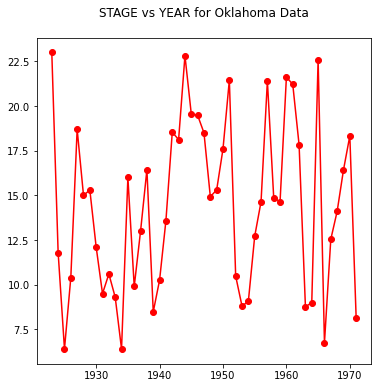

```python
import matplotlib.pyplot # the python plotting library
myfigure = matplotlib.pyplot.figure(figsize = (6,6)) # generate a object from the figure class, set aspect ratio
matplotlib.pyplot.plot(y, s ,color="red",marker="o") # The observations as points
#matplotlib.pyplot.plot(xpred, ypred, color ='blue') # the polynomial
#matplotlib.pyplot.xlabel("Input Value")
#matplotlib.pyplot.ylabel("Function Value")
mytitle = "STAGE vs YEAR for Oklahoma Data\n "
#mytitle += "Blue Markers are Observations " + "\n"
#mytitle += "Red Curve is Fitted Polynomial "+ "\n"
matplotlib.pyplot.title(mytitle)
matplotlib.pyplot.show()
```

A plot year versus discharge ( x-axis is year).

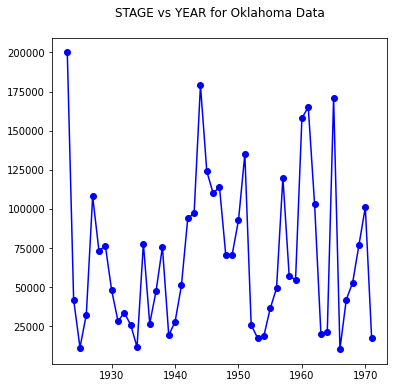

```python
q = df['DISCHARGE']
myfigure = matplotlib.pyplot.figure(figsize = (6,6)) # generate a object from the figure class, set aspect ratio
matplotlib.pyplot.plot(y, q ,color="blue",marker="o") # The observations as points
#matplotlib.pyplot.plot(xpred, ypred, color ='blue') # the polynomial
#matplotlib.pyplot.xlabel("Input Value")
#matplotlib.pyplot.ylabel("Function Value")
mytitle = "STAGE vs YEAR for Oklahoma Data\n "
#mytitle += "Blue Markers are Observations " + "\n"
#mytitle += "Red Curve is Fitted Polynomial "+ "\n"
matplotlib.pyplot.title(mytitle)
matplotlib.pyplot.show()
```

A plot the discharge versus stage (x-axis is discharge).

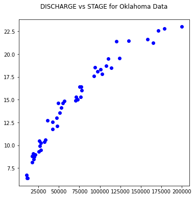

```python
myfigure = matplotlib.pyplot.figure(figsize = (6,6)) # generate a object from the figure class, set aspect ratio
matplotlib.pyplot.scatter(q, s ,color="blue",marker="o") # The observations as points
#matplotlib.pyplot.plot(xpred, ypred, color ='blue') # the polynomial
#matplotlib.pyplot.xlabel("Input Value")
#matplotlib.pyplot.ylabel("Function Value")
mytitle = "DISCHARGE vs STAGE for Oklahoma Data\n "
#mytitle += "Blue Markers are Observations " + "\n"
#mytitle += "Red Curve is Fitted Polynomial "+ "\n"
matplotlib.pyplot.title(mytitle)
matplotlib.pyplot.show()
```

Using the Weibull plotting position formula, determine the distribution parameters that fit the data for a Gamma (Log-Pearson Type III) distribution. Plot the empirical observations (use BLUE markers - no lines) and the fitted distribution (RED curve - no markers) on the same graph.

We can get the script(s) from [ENGR 1330 JupyterBook](http://54.243.252.9/engr-1330-webroot/engr1330jb/_build/html/lessons/lesson25/lesson25.html) textbook.

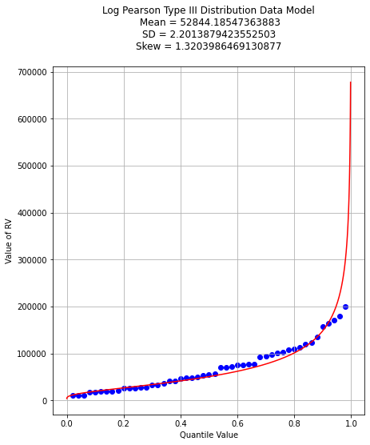

```python
import scipy.stats # import scipy stats package
import math        # import math package
import numpy       # import numpy package
# log and antilog
def loggit(x):  # A prototype function to log transform x
    return(math.log(x))
def antiloggit(x):  # A prototype function to log transform x
    return(math.exp(x))
def weibull_pp(sample): # plotting position function
# returns a list of plotting positions; sample must be a numeric list
    weibull_pp = [] # null list to return after fill
    sample.sort() # sort the sample list in place
    for i in range(0,len(sample),1):
        weibull_pp.append((i+1)/(len(sample)+1))
    return weibull_pp
def gammacdf(x,tau,alpha,beta): # Gamma Cumulative Density function - with three parameter to one parameter convert
    xhat = x-tau
    lamda = 1.0/beta
    gammacdf = scipy.stats.gamma.cdf(lamda*xhat, alpha)
    return gammacdf
#sample = beargrass['Peak'].tolist() # put the peaks into a list
sample = df['DISCHARGE'].apply(loggit).tolist() # put the log peaks into a list
sample_mean  = numpy.array(sample).mean()
sample_stdev = numpy.array(sample).std()
sample_skew  = -scipy.stats.skew(sample)
sample_alpha = 4.0/(sample_skew**2)
sample_beta  = numpy.sign(sample_skew)*math.sqrt(sample_stdev**2/sample_alpha)
sample_tau   = sample_mean - sample_alpha*sample_beta
plotting = weibull_pp(sample)
x = []; ycdf = []
xlow = (0.9*min(sample)); xhigh = (1.1*max(sample)) ; howMany = 100
xstep = (xhigh - xlow)/howMany
for i in range(0,howMany+1,1):
    x.append(xlow + i*xstep)
    yvalue = gammacdf(xlow + i*xstep,sample_tau,sample_alpha,sample_beta)
    ycdf.append(yvalue)
    # reverse transform the peaks, and the data model peaks
for i in range(len(sample)):
    sample[i] = antiloggit(sample[i])
for i in range(len(x)):
    x[i] = antiloggit(x[i])
myfigure = matplotlib.pyplot.figure(figsize = (7,8)) # generate a object from the figure class, set aspect ratio
matplotlib.pyplot.scatter(plotting, sample ,color ='blue')
matplotlib.pyplot.plot(ycdf, x, color ='red')
matplotlib.pyplot.xlabel("Quantile Value")
matplotlib.pyplot.ylabel("Value of RV")
mytitle = "Log Pearson Type III Distribution Data Model\n "
mytitle += "Mean = " + str(antiloggit(sample_mean)) + "\n"
mytitle += "SD = " + str(antiloggit(sample_stdev)) + "\n"
mytitle += "Skew = " + str(antiloggit(sample_skew)) + "\n"
matplotlib.pyplot.title(mytitle)
matplotlib.pyplot.grid(which="both")
matplotlib.pyplot.show()
```

```python
print(sample_tau)
print(sample_alpha)
print(sample_beta)
```

```
5.19685628323792
51.78185270767061
0.109657078410145
```

Estimate the discharge associated with a 25-percent chance exceedence probability (i.e. the value that is equal to or exceeded with a 1 in 4 chance).

```python
from scipy.optimize import newton

def f(x):
    sample_tau = 5.19685628323792
    sample_alpha = 51.78185270767061
    sample_beta = 0.109657078410145
    quantile = 0.7500
    argument = loggit(x)
    gammavalue = gammacdf(argument,sample_tau,sample_alpha,sample_beta)
    return gammavalue - quantile

myguess =  15000
print(newton(f, myguess))
```

```
88042.34864217619
```

So 75-th percentile (75\% chance less than, 25\% greater than) is 88,000 CFS

A resident claims that in the early 1900s a flood corresponding to a stage of 30 feet occurred at the gage location. Estimate the exceedence probability (return period) of the flow associated with this event.

30 feet is greater than 200,000 from the stage discharge plot. Then trial and error to find probability to get 200,000

```python
from scipy.optimize import newton

def f(x):
    sample_tau = 5.19685628323792
    sample_alpha = 51.78185270767061
    sample_beta = 0.109657078410145
    quantile = 0.94700 #< change this value until returns 200,000
    argument = loggit(x)
    gammavalue = gammacdf(argument,sample_tau,sample_alpha,sample_beta)
    return gammavalue - quantile

myguess =  200000
print(newton(f, myguess))
```

```
200087.39402682573
```

So roughly the reported value corresponds to a 5.3\% chance event or a 18.86-year event., not super rare.

```python
plotting[-1]
```

```
0.98
```

If we use the empirical distribution its a 2\% chance event or a 50-year flood.

Here are the same data analyzed using PeakFQ 7.3

[figure not shown]

The results are similar, PeakFQ would be the more "correct" as it used a modern EMA fitting technique which we did not attempt to replicate in python.